# Sktime_13

## Metric

#### **Load Data**

```python
import warnings
warnings.filterwarnings("ignore")
```

```python
from sktime.datasets import load_airline
from sktime.forecasting.model_selection import temporal_train_test_split

# load data
y = load_airline()
y_train, y_test = temporal_train_test_split(y, test_size=36)
```

#### **Forecast**

```
(<Figure size 1600x400 with 1 Axes>,
 <Axes: ylabel='Number of airline passengers'>)
```

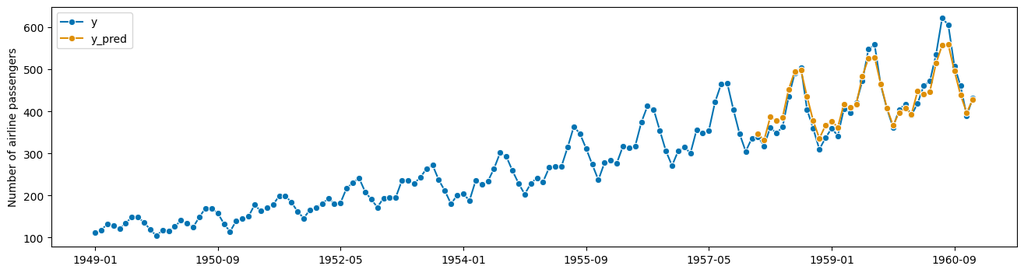

```python
from sktime.utils.plotting import plot_series
from sktime.forecasting.arima import AutoARIMA
import numpy as np

# select a forecaster
forecaster = AutoARIMA(sp=12, suppress_warnings=True)

# define forecast horizon
fh = np.arange(1, 37)

# train model
forecaster.fit(y_train)

# forecast
y_pred = forecaster.predict(fh)

# visualization
plot_series(y, y_pred, labels=["y", "y_pred"])
```

#### **$R^{2}$**

$$ R^{2} = \frac{\sum_{i = 1}^{n}|y_{i} - f_{i}|}{\sum_{i = 1}^{n}|y_{i} - \bar{y}|}$$

- $y_{i}$, true value
- $f_{i}$, predicted value
- $\bar{y} = \sum_{i = 1}^{n} y_{i}$
- Expresses the proportion of the variance in the dependent variable that is predictable from the independent variables, 1 means perfect relationship, 0 means no relationship
- $R^{2}$ is **not** an error measure metric

```python
from sklearn.metrics import r2_score
r2_score(y_test, y_pred) # 0.92
```

#### **Mean Absolute Error (MAE)**

$$ MAE = \frac{1}{n}\sum_{i = 1}^{n}|y_{i} - f_{i}|$$

- $y_{i}$, true value
- $f_{i}$, predicted value
- Range
  - $0 - \infty$, the lower the value the better and 0 means the model is perfect
- Pros
  - Easy to interpret, suitable for continuous variables, and less sensitive to outliers
- Cons
  - Need to compare with other MAE to check if this MAE is good/bad

```python
# univariate
from sktime.performance_metrics.forecasting import MeanAbsoluteError
mae = MeanAbsoluteError()
mae(y_test, y_pred)

from sktime.performance_metrics.forecasting import mean_absolute_error
mean_absolute_error(y_test, y_pred)
```

```python
# multivariate

y_true_m = np.array([[0.5, 1], [-1, 1], [7, -6]]) # 3*2
y_pred_m = np.array([[0, 2], [-1, 2], [8, -5]]) # 3*2

# ‘raw_values’, returns an error for each output
mae = MeanAbsoluteError(multioutput='raw_values')
mae(y_true_m, y_pred_m) # 0.5, 1

# ‘uniform_average’, return an error for all outputs with uniform weight
mae = MeanAbsoluteError(multioutput='uniform_average')
mae(y_true_m, y_pred_m) # 0.75

# # ‘uniform_average’, return an error, each output has different weight
mae = MeanAbsoluteError(multioutput=[0.2, 0.8])
mae(y_true_m, y_pred_m) # 0.9
```

#### **Mean Squared Error (MSE)**

$$ MSE = \frac{1}{n}\sum_{i = 1}^{n}(y_{i} - f_{i})^2$$

- $y_{i}$, true value
- $f_{i}$, predicted value
- Range
  - - $0 - \infty$, the lower the value the better and 0 means the model is perfect
- Pros
  - gives more weight to larger errors ensuring no outlier predictions with large errors
- Cons
  - sensitivity to outliers, magnify the error from a single bad prediction

```python
from sktime.performance_metrics.forecasting import MeanSquaredError
mse = MeanSquaredError()
mse(y_test, y_pred)

from sktime.performance_metrics.forecasting import mean_squared_error
mean_squared_error(y_test, y_pred)
```

#### **Root Mean Squared Error (RMSE)**

$$ RMSE = \sqrt{MSE}$$

- Range
  - - $0 - \infty$, the lower the value the better and 0 means the model is perfect
- Pros
  - penalizes larger errors more severely
  - same units as original data
- Cons
  - The magnitude of RMSE is directly related to the scale of the dependent variable making it difficult to compare RMSE values across different datasets or models with different target scales

```python
from sktime.performance_metrics.forecasting import MeanSquaredError
rmse = MeanSquaredError(square_root=True)
rmse(y_test, y_pred)

from sktime.performance_metrics.forecasting import mean_squared_error
mean_squared_error(y_test, y_pred, square_root=True)
```

#### **Mean Absolute Scaled Error (MASE)**

$$MASE = \frac{\frac{1}{n}\sum_{i = 1}^{n}|y_{i} - f_{i}|}{\frac{1}{n-1}\sum_{i=2}^{n}|y_{i} - y_{i-1}|}$$

- $y_{i}$, true value
- $f_{i}$, predicted value
- Compare the model’s error to a naive forecast, numerator is the MAE, denominator is the MAE of the naive forecast. The naive forecast is generated by equating the current forecast to the output from the last time step
- Range
  - $0 - \infty$, the lower the value the better and 0 means the model is perfect
  - if MASE < 1 indicates that the forecasting model performs better than the naive forecast; if MASE > 1, the forecast is worse than the naive forecast
- Pros
  - scale-independent
  - never gives undefined or infinite values
  - robust to Outliers
- Cons
  - the MASE values may not be meaningful if the naive forecast is not appropriate for the data

```python
from sktime.performance_metrics.forecasting import MeanAbsoluteScaledError
mase = MeanAbsoluteScaledError()
mase(y_test, y_pred, y_train = y_train)

from sktime.performance_metrics.forecasting import mean_absolute_scaled_error
mean_absolute_scaled_error(y_test, y_pred, y_train = y_train)
```

#### **Mean Squared Scaled Error (MSSE)**

$$MSSE = \frac{\frac{1}{n}\sum_{i = 1}^{n}(y_{i} - f_{i})^2}{\frac{1}{n-1}\sum_{i=2}^{n}(y_{i} - y_{i-1})^2}$$

- $y_{i}$, true value
- $f_{i}$, predicted value
- Range
  - $0 - \infty$, the lower the value the better and 0 means the model is perfect
  - if MSSE < 1 indicates that the forecasting model performs better than the naive forecast; if MSSE > 1, the forecast is worse than the naive forecast
- Pros
  - scale independence
- Cons
  - sensitive to the choice of forecasting model and naive benchmark

```python
from sktime.performance_metrics.forecasting import MeanSquaredScaledError

# sp, adjust the naive forecast and the model's forecast error to reflect the seasonal patterns in the data
msse = MeanSquaredScaledError(sp = 1)
msse(y_test, y_pred, y_train = y_train)

from sktime.performance_metrics.forecasting import mean_squared_scaled_error
mean_squared_scaled_error(y_test, y_pred, y_train = y_train)
```

```
0.7338416972789035
```

#### **Root Mean Squared Scaled Error (RMSSE)**

$$ RMSSE = \sqrt{RMSSE}$$

```python
from sktime.performance_metrics.forecasting import MeanSquaredScaledError

# sp, adjust the naive forecast and the model's forecast error to reflect the seasonal patterns in the data
msse = MeanSquaredScaledError(sp = 1, square_root=True)
msse(y_test, y_pred, y_train = y_train)

from sktime.performance_metrics.forecasting import mean_squared_scaled_error
mean_squared_scaled_error(y_test, y_pred, y_train = y_train, square_root=True)
```

```
0.8566456077508969
```

#### **Geometric Mean Absolute Error (GMAE)**

$$GMAE = (\prod_{i=1}^{n}|y_{i}-f_{i}|)^{1/n}$$

- $y_{i}$, true value
- $f_{i}$, predicted value
- Range
  - $0 - \infty$, the lower the value the better
- Pros
  - places greater emphasis on large errors compared to traditional error metrics like Mean Absolute Error (MAE) or Root Mean Squared Error (RMSE)
  - robust to outliers
- Cons
  - when any prediction is accurate, meaning that the absolute error between the predicted values and the actual values is zero for all observationsis zero

```python
from sktime.performance_metrics.forecasting import GeometricMeanAbsoluteError
gmae = GeometricMeanAbsoluteError()
gmae(y_test, y_pred)

from sktime.performance_metrics.forecasting import geometric_mean_absolute_error
geometric_mean_absolute_error(y_test, y_pred)
```

#### **Geometric Mean Squared Error (GMSE)**

$$GMSE = (\prod_{i=1}^{n}(y_{i}-f_{i})^2)^{1/n}$$

- $y_{i}$, true value
- $f_{i}$, predicted value
- Range
  - $0 - \infty$, the lower the value the better
- Pros
  - Suitability for skewed data
  - robust to outliers
- Cons
  - assumption of squared error

```python
from sktime.performance_metrics.forecasting import GeometricMeanSquaredError
gmse = GeometricMeanSquaredError()
gmse(y_test, y_pred)

from sktime.performance_metrics.forecasting import geometric_mean_squared_error
geometric_mean_squared_error(y_test, y_pred)
```

```
166.83741162579844
```

#### **Root Geometric Mean Squared Error (GMSE)**

$$ RGMSE = \sqrt{GMSE}$$

```python
from sktime.performance_metrics.forecasting import GeometricMeanSquaredError
rgmse = GeometricMeanSquaredError(square_root=True)
rgmse(y_test, y_pred)

from sktime.performance_metrics.forecasting import geometric_mean_squared_error
geometric_mean_squared_error(y_test, y_pred, square_root=True)
```

#### **Mean Absolute Percentage Error (MAPE)**

- Asymmetric $$ MAPE = \sum_{i = 1}^{n} |\frac{y_{i} - f_{i}}{y_{i}}|$$
- Symmetric $$ sMAPE = \frac{2}{n} \sum_{i = 1}^{n} \frac{|y_{i} - f_{i}|}{|y_{i}|+|f_{i}|}$$
- $y_{i}$, true value
- $f_{i}$, predicted value
- output non-negative floating point which is in fractional units rather than percentage
- Range
  - MAPE = 0%, perfect forecast accuracy
  - 0% < MAPE < 100%, indicates forecast accuracy between perfect and no accuracy
  - MAPE = 100%, indicates no forecast accuracy
  - MAPE > 100%: indicates poor forecast accuracy
- Pros
  - provides a percentage-based measure of forecast accuracy
  - scale independence
- Cons
  - MAPE can encounter division by zero issues

```python
from sktime.performance_metrics.forecasting import MeanAbsolutePercentageError
mape = MeanAbsolutePercentageError(symmetric=False)
mape(y_test, y_pred)

smape = MeanAbsolutePercentageError(symmetric=True)
smape(y_test, y_pred)

from sktime.performance_metrics.forecasting import mean_absolute_percentage_error
mean_absolute_percentage_error(y_test, y_pred, symmetric=False)
mean_absolute_percentage_error(y_test, y_pred, symmetric=True)
```

#### **Mean Squared Percentage Error (MSPE)**

- Asymmetric $$ MSPE = \sum_{i = 1}^{n} (\frac{y_{i} - f_{i}}{y_{i}})^2$$
- Symmetric $$ sMSPE = \frac{1}{n} \sum_{i = 1}^{n} (\frac{y_{i} - f_{i}}{(y_{i}+f_{i})/2})^2$$
- $y_{i}$, true value
- $f_{i}$, predicted value
- output non-negative floating point which is in fractional units rather than percentage
- Range
  - MSPE = 0, indicates perfect forecast accuracy
  - MSPE > 0, indicates the presence of forecast errors
- Pros
  - Sensitive to large errors
  - scale independence
- Cons
  - can be excessively influenced by small actual value
  - can give excessive weight to outliers
  - can encounter division by zero issues

```python
from sktime.performance_metrics.forecasting import MeanSquaredPercentageError
mspe = MeanSquaredPercentageError(symmetric=False)
mspe(y_test, y_pred)

smspe = MeanSquaredPercentageError(symmetric=True)
smspe(y_test, y_pred)

from sktime.performance_metrics.forecasting import mean_squared_percentage_error
mean_squared_percentage_error(y_test, y_pred, symmetric=False)
mean_squared_percentage_error(y_test, y_pred, symmetric=True)
```

```
0.002429633853870557
```

#### **Root Mean Squared Percentage Error (RMSPE)**

$$ RMSPE = \sqrt{MSPE}$$

```python
from sktime.performance_metrics.forecasting import MeanSquaredPercentageError
mspe = MeanSquaredPercentageError(symmetric=False, square_root=True)
mspe(y_test, y_pred)

smspe = MeanSquaredPercentageError(symmetric=True, square_root=True)
smspe(y_test, y_pred)

from sktime.performance_metrics.forecasting import mean_squared_percentage_error
mean_squared_percentage_error(y_test, y_pred, symmetric=False, square_root=True)
mean_squared_percentage_error(y_test, y_pred, symmetric=True, square_root=True)
```

```
0.049291316211585966
```

#### Median Absolute Error (MedAE)

$$ MedAE = median(|y_{1}-\hat{y}_1|, ..., |y_{n}-\hat{y}_n|)$$

- $y_{i}$, true value
- $\hat{y}_{i}$, predicted value
- A non-negative floating point; the best value is 0.0
- Pros
  - robust to outliers

```python
from sktime.performance_metrics.forecasting import MedianAbsoluteError
mdae = MedianAbsoluteError()
mdae(y_test, y_pred)
```

[output not shown]

```python
from sktime.performance_metrics.forecasting import median_absolute_error
median_absolute_error(y_test, y_pred)
```

[output not shown]

#### Median Absolute Scaled Error (MedASE)

$$ MedASE = \frac{median(|y_{1}-\hat{y}_1|, ..., |y_{n}-\hat{y}_n|)}{{\frac{1}{n-1}\sum_{i=2}^{n}|y_{i} - y_{i-1}|}}$$

- $y_{i}$, true value
- $\hat{y}_{i}$, predicted value
- Pros
  - more robust to error outliers than MASE
  - can be used to compare forecast methods on a single series or between series
  - will not give infinite or undefined values unless the training data is a flat timeseries

```python
from sktime.performance_metrics.forecasting import MedianAbsoluteScaledError
mdase = MedianAbsoluteScaledError()
mdase(y_test, y_pred, y_train=y_train)
```

[output not shown]

```python
from sktime.performance_metrics.forecasting import median_absolute_scaled_error
median_absolute_scaled_error(y_test, y_pred, y_train=y_train)
```

[output not shown]

#### Reference

- [Performance metrics](https://www.sktime.net/en/stable/api_reference/performance_metrics.html)
- [Mean Absolute Scaled Error (MASE) in Forecasting](https://medium.com/@ashishdce/mean-absolute-scaled-error-mase-in-forecasting-8f3aecc21968)